# هوش مصنوعی

## پروژه دوم - الگوریتم ژنتیک

### دکتر فدایی - دکتر مرادی

### محیا قینی -810196615

###### آبان 1399

## هدف پروژه

در این پروژه می خواهیم با روشی مناسب برای مسئله هایی با فضای حالت بزرگ آشنا شویم. این روش به طور کل با نام الگوریتم ژنتیک شناخته می شود که برگرفته از طبیعت است. در ادامه با قسمت های مختلف از این الگوریتم و تاثیر پیاده سازی های مختلف هر قسمت بر سرعت نتیجه گیری و تاثیرات آن پیاده سازی صحبت خواهیم کرد.

## صورت مسئله

به ما اطلاعات ورودی و خروجی تعدادی مدار داده شده است. و حال از ما خواسته شده مجموعه ای از گیت ها انتخاب کنیم که که برای هر کدام از این ورودی ها خروجی مطابق با خروجی داده شده را تولید کند. در مجموع می توانیم از شش گیت انتخاب کنیم. همانطور که میبینیم فضای حالت بسیار گسترده است و با روش های سرچ معمول حل این مسئله نیازمند زمان زیادی است. بدین جهت از ما خواسته شده طی چند قدم و با کمک الگوریتم ژنتیک این مسئله را حل نماییم. روش محاسبه خروجی هم بدین گونه است که دو ورودی اول به گیت اول داده می شوند، خروجی با ورودی بعدی به گیت بعد و به همین گونه تا آخرین ورودی پیش می رویم بنابراین تعداد گیت هایی که می خواهیم یکی کمتر از تعدا ورودی های داده شده است.

## دیتای داده شده

در فایل "truth_table.csv" اطلاعات ورودی و خروجی 1024 مدار داده شده است. این اطلاعات به شکل 10 ورودی و یک خروجی است. این داده ها به صورت string هستند و نشان می دهند آن متغیر true هست یا false. از این داده ها برای تست مجموعه گیت هایی که پیشنهاد شده است؛ استفاده می کنیم. زمانی می دانیم گیت های پیشنهادی صحیح هستند که به ازای تمام سطرهای این فایل خروجی داده شده را ایجاد کند.  
در ادامه گام های پیشنهادی در پروژه و گامهایی که برای حل مسئله پیموده شده است، توضیح داده خواهد شد:

## فاز اوّل: مشخص کردن مفاهیم ژن، کروموزوم در مسئله

مهم ترین و ابتدایی ترین قدم حل مسائل با الگوریتم ژنتیک، تعریف صحیح و دقیق ژن و در نتیجه آن کروموزوم است. در این مسئله با توجه به تعریف مسئله و خروجی که از آن میخواهیم به دست آوریم ژن هایمان را گیت ها تعریف می کنیم. در نتیجه آن کروموزوم می شود رشته ای از گیت ها که طول آن یکی کمتر از تعداد ورودی هایی است که به ما داده شده است. کار با این ژن و کروموزوم ها راحت است و اعمال توابع بر آن ها مشکلی ندارد. بنابراین برای ژن ها یک متغیر global به شکل زیر تعریف می کنیم:

```python
possibleGenes = ["AND", "NAND", "OR", "NOR", "XOR", "XNOR"]
```

به طور کلی تابعی پیاده سازی شده است برای آن که از این لیست ژنی به صورت تصادفی انتخاب شود، به شکل زیر:

```python
def getRandomGene(self):
        return random.choice(possibleGenes)
```

این تابع برای ساخت کروموزوم های نسل اول استفاده می شود. بدین دلیل که می خواهیم ساخت کروموزوم ها بدون هیچ جهت گیری خاصی باشد، رندوم بهترین شکل است.  
همچنین این تابع در مراحل بعدی حین جهش هم به کار می رود که به آن در ادامه اشاره خواهیم کرد.

## فاز دوم: تولید جمعیت اولیه

در این قسمت باید نسل اول را با مجموعه ای از کروموزوم ها که بالا تعریف کردیم بسازیم. نسل ها را به شکل یک heapq نگه می داریم تا بتوانیم به راحتی مجموعه ای از کروموزوم ها که براساس معیار اعتبارسنجی مرتب شده است به دست آوریم. پیاده سازی ایجاد نسل اولیه به شکل زیر است:

```python
for i in range (population):
        rand = Chromosome.createRandom()
        ch = Chromosome(rand)
        generation.add(ch)
        generation.sort()
```

همانطور که در بالا میبینیم ابتدا برا کروموزوم رشته ای از ژن ها به صورت رندوم میسازیم و سپس از آن رشته رندوم object مربوط به کروموزوم را میسازیم. سپس آن را به نسل اضافه می کنیم. در آخر یک لیست مرتب شده از کروموزوم های اضافه شده بر اساس معیار سازگاری شان که در ادامه خواهیم گفت به دست می آوریم. در ادامه با این لیست مرتب شده کار خواهیم کرد.  
نکته مهم دیگر متغیر population به کار رفته است که نشان دهنده جمعیت نسل هاست. در اینجا این متغیر به صورت global تعریف شده است تا بتوانیم با اعداد مختلف برنامه را تست کنیم و مقایسه کنیم. پس از توضیح کلی الگوریتم توضیحی در این رابطه خواهیم داد.

## فاز سوم: پیاده سازی و مشخص کردن معیار سازگاری

عاملی که باعث می شود ما در الگوریتم بتوانیم پیش برویم و بین کروموزوم ها با سنجه ای عددی تفاوت قائل شویم یک معیار سازگاری دقیق است. در اینجا معیار سازگاری برای هر کروموزوم تعداد سطر هایی از فایل داده شده است که به ازای آن ورودی ها خروجی خواسته شده را تولید کند. بدین شکل کروموزوم هایی که با محیط سازگارترند بدین معنی که منطبق با سطر های بیشتری هستند معیار سازگاری بیشتری هستند. برای پیاده سازی این قسمت توابع و قسمت های مختلفی پیاده سازی شد که در ادامه به آنها اشاره خواهیم کرد:  
- تعریف خروجی های هر گیت:  
برای این قدم تابع زیر را تعریف شده که یک دیکشنری دارد با کلید گیت ها و خروجی متناسب با هر کدام.

```python
def getEachResult(self,input1, input2, operator):
        operation = {
            "AND": (input1 and input2),
            "NAND": (not(input1 and input2)),
            "OR": (input1 or input2),
            "NOR": (not(input1 or input2)),
            "XOR": (input1 ^ input2),
            "XNOR": (not(input1 ^ input2))
        }
        return operation.get(operator)
```

- تعریف محاسبه خروجی مجموعه ورودی ها به ازای مجموعه از گیت ها:  
بدین جهت تابعی تعریف کردیم که مجموعه ورودی ها و مجموعه گیت ها را بگیرد و با کمک آنها مجموعه از خروجی ها را نیز تولید کند و با کمک عباراتی نظیر به نظیر و با ترتیبی خاص خروجی کلی را تولید کند.

```python
def getResultedOutput(self, row, operators):
        inputs = self.getInputs(row)
        outputs = []
        for i in range(len(operators)):
            if i == 0:
                outputs.append(self.getEachResult(inputs[i], inputs[i+1], operators[i]))
            else:
                outputs.append(self.getEachResult(outputs[i-1], inputs[i+1], operators[i]))
        return outputs[-1]
```

- محاسبه کلی معیار سازگاری:  
بدین جهت تابع زیر را تعریف کردیم که برای هر سطر ابتدا با کمک تابع بالا خروجی متناسب با گیت های داده شده را به دست می آورد. سپس با خروجی نوشته شده در سطر مقایسه می کند و در صورت برابری یک واحد به سازگاری این کروموزوم اضافه می کند.

```python
def calculateFitness(self):
        t = Test()
        fitness = 0
        for row in Test.rows[1:]:
            res = t.getResultedOutput(row, self.chromosome)
            actualRes = t.getWantedOutput(row)
            if(res == actualRes):
                fitness += 1
        return fitness
```

## فاز چهارم: پیاده سازی mutation و crossover و تولید جمعیت بعدی

حال برای رسیدن به جواب باید نسل بعدی را تولید کنیم و همانطور تا زمانی که به کروموزومی با معیار سازگاری برابر با تعداد سطرهای فایل ورودی برسیم(بدون در نظرگرفتن سطر اوّل که نام ستون هاست)ادامه دهیم. حال مهم ترین فاکتور در سرعت رسیدن به پاسخ تولید مناسب نسل بعدی از این نسل است. بدین جهت ابتدا یک انتخاب از نسلی که داریم باید انجام شود که در فاز پنجم توضیح داده خواهد شد. سپس باید روی کروموزوم های انتخاب شده عملیات crossover و mutation را پیاده سازی کنیم که در ادامه هر یک را توضیح می دهیم:  
-crossover:

```python
def crossover(self, other):
        probability = random.uniform(0, 1)
        if probability <= 0.25:
            return (self, other)
        else:
            point1 = int(random.uniform(0, targetLen/2))
            point2 = int(random.uniform((targetLen/2)+1, targetLen-2))
            new1 = self.chromosome[0:point1] + other.chromosome[point1:point2] + self.chromosome[point2:]
            new2 = other.chromosome[0:point1] + self.chromosome[point1:point2] + other.chromosome[point2:]
            return (Chromosome(new1), Chromosome(new2))
```

ابتدا عددی را بین صفر و یک انتخاب می کنیم و اگر کمتر از بیست و پنج صدم بود همان دو کروموزوم اولیه را باز می گردانیم. بدین معنا که با احتمال بیست و پنج درصد کروموزوم ها را تغییر نمی دهیم. اما به احتمال هفتاد و پنج درصد دو کروموزوم کنار هم را به شکل زیر تغییر می دهیم:  
دیدگاه کلی crossover از دو نقطه است. بدین شکل که دو نقطه را به صورت تصادفی انتخاب می کنیم. بعد و قبل این نقاط را تغییر نمیدهیم و بین آنها را با همان قسمت از کروموزوم دیگر تکمیل میکنیم.  
-mutation:

```python
def mutation(self, size):
        probability = 1 - (self.fitness/size)
        newChromosome = []
        for gene in self.chromosome:
            chance = random.uniform(0, 1)
            if chance <= probability:
                gene = self.getRandomGene()
            newChromosome.append(gene)
        return Chromosome(newChromosome)
```

در این قسمت روی یک کروموزوم تغییر ایجاد می کنیم و هر ژن آن را با احتمالی به صورت تصادفی با ژن دیگری جایگزین می کنیم. این احتمال دیگر تصادفی محاسبه نمی شود بلکه با معیار سازگاری کروموزوم مرتبط است. بدین شکل که هر چه کروموزوم با محیط سازگارتر است احتمال تغییر آن کمتر باشد. بنابراین احتمال تغییر را برابر با درصد عدم سازگاری در نظر میگیریم. سپس برای هر بیت براساس این احتمال تصمیم گیری می شود ژن تغییر کند یا خیر.

## فاز پنجم: سوالات

### سوال اول:

معیار تناسب باید به گونه ای انتخاب شود که هر چه به هدف نزدیک تر میشویم این مقدار برای کروموزوم بیشتر شود، بدین معنا که این کروموزوم با محیط سازگارتراست و ما را به هدفمان نزدیک تر میکند. ما اینجا هدفمان رسیدن به مجموعه گیت هایی هست که برای تمام سطرهای ورودی فایل داده شده به ازای ورودی ها خروجی داده شده را ایجاد نماید. بنابراین بهترین راه فهمیدن میزان سازگاری کروموزومی که در حال حاضر داریم با محیط آن است که از همین معیار استفاده کنیم، بدین معنی که ببینیم کروموزوم چه مقدار از سطرها را مناسب پاسخ می دهد، هرچه این تعداد بیشتر باشد امید موفقیت این کروموزوم بیشتر است و با محیط سازگارتر است. این دقیقاً معیاری است که در حل این مسئله استفاده شده است.

### سوال دوم:

در این سوال روش selection را توضیح خواهیم داد. در هنگام انتخاب دو مورد باید در نظر گرفته شود:  
1) به گونه ای انتخاب کنیم که کروموزوم ها با معیار سازگاری بالاتر بیشتر احتمال انتخاب شدن داشته باشند و فرزندان آن ها در نسل بعد قرار گیرد(مطابق انتخاب طبیعی موجود درطبیعت)  
2) به گونه ای انتخاب کنیم که جهت گیری مستقیم به یک سمت نداشته باشیم و مانع گوناگونی و گستردگی در کروموزوم های نسل جدید نشویم(بدین جهت که شاید این کروموزوم ها سازگاری بالایی نداشته باشند اما شاید فرزندان آنها سریعتر ما را به پاسخ و هدفمان برسانند.)  
براساس دو نکته گفته شده در بالا ما روشی انتخاب کردیم که یک کروموزوم خاصی را حتماً به نسل بعد منتقل نکند و به همه شانس انتخاب شدن بدهد و همچنین کروموزوم های بهتر که اول لیست مرتب شده نسل ها قرار دارند شانس بیشتری داشته باشند. بدین جهت دو تابع پیاده کردیم. یکی تابع ساخت احتمال ها و وزن هر یک از کروموزوم ها که در دفعه اول به چهار قسمت تقسیم کردیم و از 4 به 1 وزن دهی کردیم. تابع بعدی تابع کلی انتخاب که با کمک وزن های تابع قبل و تابع choices کتابخانه random پایتون کروموزوم ها را انتخاب میکند.

```python
def calculateProbability(self):
        probability = []
        for i in range(len(Generation.sortedGeneration)):
            if i < int(0.25 * population):
                probability.append(4)
            elif i < int(0.5*population):
                probability.append(3)
            elif i < int(0.75*population):
                probability.append(2)
            else:
                probability.append(1)
        return probability

    def select(self, inGeneration, probability):
        selection = random.choices(inGeneration, weights = probability, k = len(inGeneration))
        return selection
```

### سوال سوم:

فاز بعد از انتخاب در الگوریتم ژنتیک عملیات crossover و mutation است.دلیل نیاز به هردو آنها این است که کروموزوم های انتخاب شده از نسل قبل را عیناً به نسل جدید منتقل نکنیم و با تغییر آنها گوناگونی بیشتری در کروموزوم ها ایجاد کنیم.crossover روی دو کروموزوم شکل میگیرد و آنها را ترکیب میکند و ایده اش این است که شاید با ترکیب کروموزوم ها بتواند قسمت هایی که در کروموزوم ها باعث سازگاری شده اند را در کنار هم در یک کروموزوم بگذارد. توضیح پیاده سازی آن در فاز چهارم آمده است. احتمال crossover باید بالا در نظر گرفته شود تا با شانس بالاتری کروموزوم ها با هم ترکیب شوند و کروموزوم های گوناگون تر و جدید تری ایجاد شود.  
mutation روی یک کروموزوم ایجاد می شود. با این دیدگاه که بعد از ترکیب کروموزوم ها گوناگونی را با تغییر ژن های یک کروموزوم بالاتر ببریم و شاید این تغییر کروموزوم را مناسب تر کند. توضیح پیاده سازی این قسمت هم در فاز چهارم آمده است. درباره احتمال mutation هم باید گفت این احتمال با این دیدگاه ایجاد شده که کروموزومی که با محیط سازگارتر است را با احتمال کمتری ژن هایش را تغییر دهیم تا با یک تغییر اشتباه سازگاریش را کم نکنیم.

### سوال چهارم:

در مقطعی از اجرای الگوریتم ممکن است کروموزوم ها و معیار سازگاری های یکسانی را در چند نسل متفاوت ببینیم و دلیل آن تصمیم گیری ها در انتخاب والد و عملیات crossover و mutation است. ممکن است در چند نسل والد ها از کروموزوم ها با سازگاری بالاتر انتخاب شود و با crossover هم تنها از دو کروموزوم خوب قسمت هایی را جدا کنیم و ترکیب کنیم که ساختاری مشابه حالت قبلی ایجاد کند که تفاوت چندانی در معیار سازگاری ایجاد نکند و همچنین با احتمالی که برای mutation در نظرگرفته ایم چون معیار سازگاری بالایی دارد با احتمال بسیار کمی تغییر می کند و کروموزوم یکسان به ما می دهد.از راه حل های این مشکل می تواند به موارد زیر اشاره کرد:  
- تغییر معیار سازگاری به گونه ای که یک دسته از کروموزوم ها را ناگهان بی ارزش نکند.  
- تغییر روش انتخاب به گونه ای که هنگام گیر افتادن بتواند از کروموزوم های کم ارزش تر با احتمال بالاتر انتخاب کند تا با ترکیب آنها گستردگی به الگوریتم برگردد.  
- تغییر crossover به گونه ای که هنگام گیر افتادن با احتمال کمتری همان والد ها را به عنوان فرزندان به نسل بعد انتقال دهد.  
- تغییر mutation به گونه ای که هنگامی که گیر افتادیم با احتمال بالاتری حتی برای کروموزوم های خوب تغییر ایجاد کنیم.  
راه چهارم از آنجایی که بر روی یک الگوریتم تاثیر مستقیم دارد و همچنین برای کروموزم های خوب که عامل گیر افتادن ما هستند احتمال تغییر را بالا می برد به عنوان روش مناسب انتخاب و پیاده سازی شد.  
بدین روش که بهترین معیار در چند نسل بررسی می شود و در صورت تکرار در چند مرحله یک flag ای فعال می شود و در صورت فعال بودن آن mutation در دور بعد مقداری را به احتمال تغییر اضافه می کند تا کروموزوم بهتر هم شانس بالاتری برای تغییر داشته باشد. این اعداد ثبت یعنی تعداد نسل های تکراری و مقدار افزایش احتمال هایپرپارامتر هستند که نتیجه بررسی آنها در آینده بیان می شود.

## توضیحی کلی بر پیاده سازی

در پیاده سازی سعی شده است با کمک گرفتن از پیاده سازی شی گرا نظم و در پایان رفع مشکل در کد را ساده تر کنیم. سه کلاس اصلی داریم:  
-Chromosome:  
در این کلاس توابعی مورد نیاز برای مدیریت کروموزوم ها پیاده سازی شده اند. از جمله ایجاد رندوم ژن ها و در نتیجه ساخت کروموزوم ها و محاسبه سازگاری و crossover و mutation.  
-Generation:  
این کلاس عملاً یک لیست با ساختار heapq است که برای نگه داری کروموزوم های هر نسل استفاده می شود. توابع مربوط به نسل ها مانند انتخاب از نسل ها در آن آمده است.  
-Test:  
این کلاس برای مدیریت و کار با فایلی است که به عنوان تست داده شده است پیاده سازی شده است.توابع مدیریت ورودی مانند تشخیص ورودی ها و خروجی های هر مدار و محاسبه خروجی با گیت ها در این کلاس وجود دارد.  
علاوه بر این سه کلاس دو متغیر global داریم:  
- PossibleGenes:  
ژن هایی که می توان در ساخت کروموزوم از آنها استفاده کرد.  
-population  
جمعیت هر نسل.  
همچنین یک تابع main داریم که شکل کلی الگوریتم ژنتیک در آن پیاده شده است. به ترتیب نسل اولیه را می سازد سپس چک میکند به هدف رسیدیم یا نه. انتخاب را انجام می دهیم. بعد crossover و بعد mutation را انجام می دهیم و نسل جدید را می سازیم. تا به هدف برسیم ادامه می دهیم.  
نکته دیگری که به آن باید توجه شود آن است که مقادیر داده شده در ورودی string هستند و قبل از هر کاری آن ها را به boolean باید تبدیل کنیم و این کار با مقایسه string با "TRUE" انجام می شود.

## Hyper parameter

این پارامتر ها پارامترهایی هستند که با تغییر آنها سرعت یادگیری تغییر می کند. تعیین اینکه به طور دقیق کدام مقدار برای این پارامتر در مسئله بهتر است ساده نیست. چون تعداد زیادی متغیر با مقدار رندوم داریم که اگر آن پارامتر را تغییر دهیم و دوباره برنامه را اجرا کنیم، هیچ تضمینی وجود ندارد که مقادیر رندوم ثابت بمانند و بتوانیم مقایسه دقیقی داشته باشیم. حال این پارامتر ها را در این پروژه بیان میکنیم و مروری بر مقداری که به آنها داده ایم و دلیل آن انجام میدهیم:  
-جمعیت:  
جمعیتی که برای نسل ها در نظر میگیریم بسیار مهم است چون اگر از یک حدی بیشتر باشد تنها زمان اجرا را زیاد می کند بدون تاثیر در سرعت رسیدن به هدف و اگر از یک حدی کمتر باشد گستردگی زیادی در کروموزوم های نسل ها وجود ندارد و در نسل های دیرتری به جواب خواهیم رسید. بنابراین باید حالتی میانه را در نظر گیریم. در ادامه تعدادی نتیجه مربوط به جمعیت های متفاوت آمده است. تاگید می شود الزاماً خوب بودن نتیجه در یکی از این حالات به معنای خوب یودن همیشگی نیست به دلیل وجود تعداد زیادی متغیر تصادفی.

#### جمعیت = 100

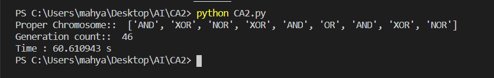

#### جمعیت = 1000

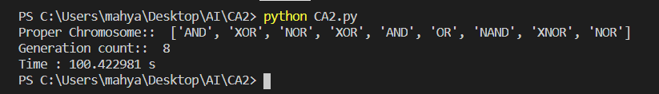

#### جمعیت = 1500

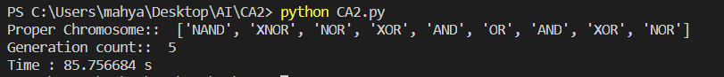

#### جمعیت = 2000

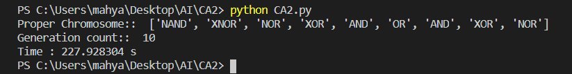

| زمان | نسل جواب | جمعیت |
| --- | --- | --- |
| 60s | 46 | 100 |
| 100s | 8 | 1000 |
| 85s | 5 | 1500 |
| 228s | 10 | 2000 |

همانطور که میبینیم در حالت جمعیت برابر با 1500، در نسل پنجم و زمان معقولی نسبت به این حجم جمعیت به جواب رسیدیم. اما در جمعیت برابر 2000 هم در نسل دیرتر و هم زمان دیرتر به هدف رسیدیم. باز هم تاکید میکنم این بدین معنا نیست الزاماً 1500 جمعیت مناسبی است.

- احتمال crossover  
همانطور که بالاتر هم گفته شد ما احتمال را به صورت بیست و پنج درصد بدون تغییر و هفتاد و پنج درصد تغییر در نظر گرفتیم. باید احتمال تغییر بالاتر باشد تا از رو کروموزوم های نسل قبل با تغییر کروموزوم های جدیدی ایجاد شود و گستردگی در نسل ها به وجود آید. البته بیش از حد بالا بردن این احتمال مناسب نیست زیرا کروموزوم هایی که خوب هستند را به احتمال بیشتری ترکیب می کنیم و ممکن است سازگاری آنها را کاهش دهیم.

#### احتمال crossover = 0.75

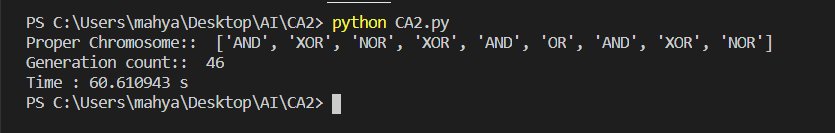

#### احتمال crossover = 0.9

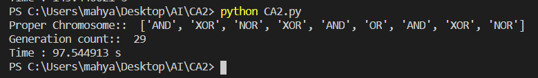

- احتمال mutation  
همانطور که گفته شد این احتمال به گونه ای پیاده سازی شده که زمانی که به یک کروموزوم با سازگاری بالا رسیدیم هر ژن احتمال کمتری برای تغییر داشته باشد. در کل این احتمال نباید زیاد باشد چون باعث خراب شدن کروموزوم سازگارتر می شود. امّا این کم بودن ممکن است باعث گیر افتادن در یک حالت شویم. که برای آن راه حلی ارائه شد و همان راه حل دو پارامتر دیگر ایجاد کرد:  
× تعداد بار های تکرار تا بگوییم گیر افتادیم:  
بدین معنا که بعد از چند دور که معیار ها تغییر نکردند بگوییم گیر افتادیم و تابع جهش را تغییر دهیم. ما بعد از دوبار را در نظر گرفتیم. هر چه زودتر این گیر افتادن مشخص شود بهتر است.  
× مقدار افزایش احتمال تغییر:  
بدین معنا که اگر در یک حالتی با سازگاری بالا گیر افتادیم احتمال جهش را به چه اندازه تغییر دهیم. ما تغییر به اندازه 0.1 را در نظر گرفتیم. نباید مقدار تغییر چنان زیاد باشد که تعداد زیادی از ژن ها تغییر کنند و از آن سازگاری خوب دور شویم.  
در ادامه دو حالت را نشان دادیم اعداد روبروی A نشان دهنده مقدار سازگاری کروموزوم است.

#### بدون تغییر و گیر افتادن مداوم

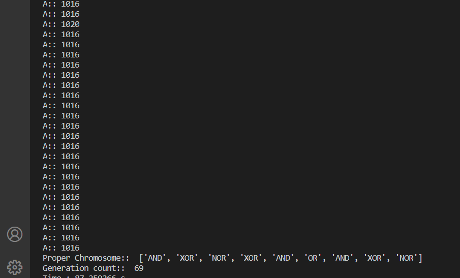

#### تغییر احتمال 0.1 و بعد از دوبار تکرار کروموزوم:

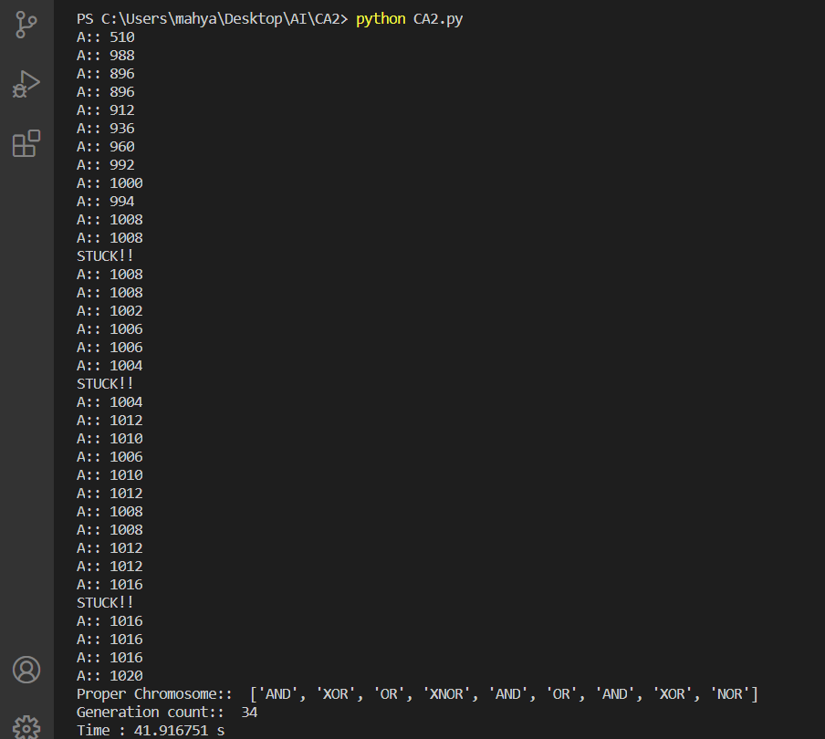

#### تغییر احتمال 0.2 و بعد از سه بار تکرار کروموزوم:

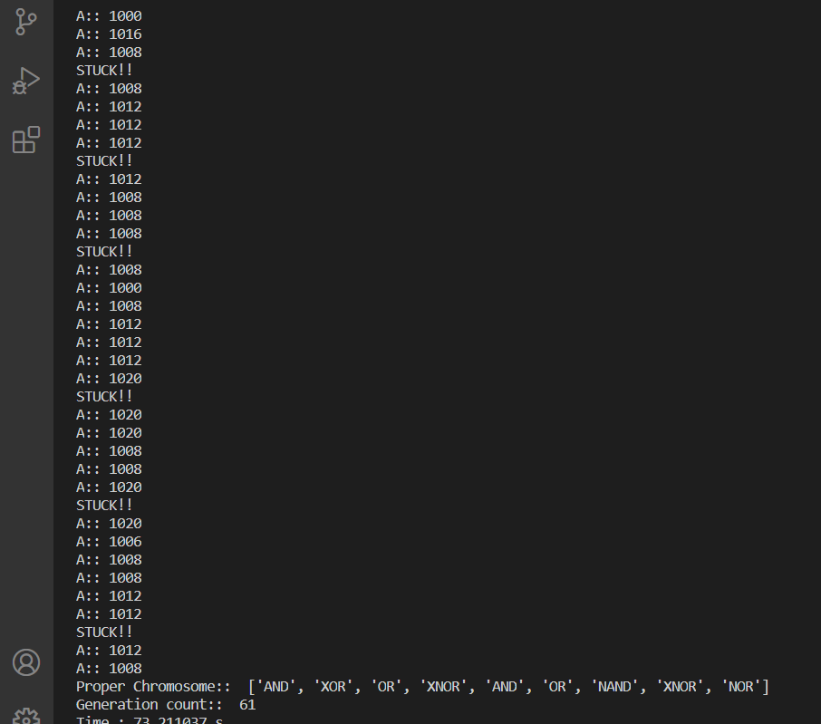

- معیار انتخاب و وزن دهی  
این مورد در فاز پنجم سوال دوم توضیح داده شد.البته حالت دیگری هم برای انتخاب امتحان شد که کد آن به صورت کامنت در کد اصلی قابل مشاهده است. بدین صورت که یک چهارم اولی که کروموزوم های خوبی هستند به طور کامل و به حتم انتخاب و به نسل بعد منتقل شوند و بقیه کروموزوم ها وزن دهی شوند. اما این روش بسیار برنامه را کند می کرد که به دلیل جهت گیری خاص آن بود.

## نتیجه گیری

الگوریتم ژنتیک در کل برای حل مسائل با فضای حالت بزرگ و گسترده یا ناشناس بسیار مناسب است امّا میزان تناسب و قدرت آن بسیار وابسته به نوع پیاده سازی است. انتخاب روش مناسب برای محاسبه میزان سازگاری از اهمیت بالایی برخوردار است. همچنین انتخاب روش صحیح crossover و mutation هم حائز اهمیت است از آنجا که این موارد باعث تغییر کروموزوم ها هستند. تغییر مناسب و خوب می تواند ما را سریعتر به جواب برساند، تغییر غیر مناسب ما را در یک حالت بهینه محلی گیر می اندازد و حتی از جواب دور می کند. انتخاب جمعیت مناسب و به دور از جهت گیری هم از دیگر نکات مهم است. باید سعی شود به هیچ عنوان نسل ها را به یک سمت خاص هدایت نکنیم تا از حالت ها خوب ممکن دیگر دور نشویم.